```r
knitr::opts_chunk$set(echo = TRUE)

library(data.table)
library(plyr)
library(readr)
```

```r
library(stargazer)
library(ggplot2)
library(dplyr)
library(showtext)
library(showtext)
```

### Introduction

In this paper I examine mental health trends in the United States during the COVID-19 pandemic, as well as the heterogeneity of these trends among subgroups including age, sex, and education level. Specifically, I analyze data on the proportion of adults in the United States exhibiting symptoms of anxiety or depressive disorder. I expect to find a positive correlation between the likelihood of experiencing symptoms and the number of daily Covid cases and deaths. I also expect to find that minority groups report worse mental health on average.

### Data and Preliminary Analysis

In my model, my outcome variable of interest is a dummy variable indicating 1 if the individual exhibits symptoms of depressive or anxiety disorder (*DEP_ANX*). My independent variables are the 7-day rolling average of daily cases and deaths per capita. I control for race, income level, education level, age, marital status, geographic region, and gender.

```r
# load data
data <- read.csv("~/Desktop/data projects/COVID-mental-health/finaldata.csv")

# ensure categorical variables are factors and date is date type
data$dates <- as.Date(data$dates)
data$EST_ST <- as.factor(data$EST_ST) # state
data$MS <- as.factor(data$MS) # marital status
data$RRACE <- as.factor(data$RRACE) # race
data$EEDUC <- as.factor(data$EEDUC) # education level
data$REGION.y <- as.factor(data$REGION.y) # region
data$INCOME <- as.factor(data$INCOME) # income level
data$AGERANGE <- as.factor(data$AGERANGE) # age range
data$EGENDER <- as.factor(data$EGENDER) # gender

uscovid <- read.csv("~/Desktop/data projects/COVID-mental-health/uscovid.csv", stringsAsFactors = F)
uscovid[is.na(uscovid)] <- 0
uscovid$date <- as.Date.character(uscovid$date)
```

```r
X <- model.matrix(~ DEP_ANX + EGENDER + MS + INCOME + AGERANGE +
                  RHISPANIC + RRACE + EEDUC + REGION.y - 1 , data=data,
                  na.action = "na.pass")
X.df <- data.frame(X)
colnames(X.df) <- c("dep_anx",
                   "gender-female", "gender-male",
                   "maritalstatus-widowed","maritalstatus-divorced",
                   "maritalstatus-separated","maritalstatus-never",
                   "income 25-35k", "income 35-50k",
                   "income 50-75k", "income 75-100k", "income 100-150k",
                   "income 150-200k", "income >200k",
                   "age 30-40", "age 40-50",
                   "age 50-60", "age 60-70", "age 70-80", "age >80",
                   "nonhispanic",
                   "race-black", "race-asian", "race-other",
                   "educ-some hs", "educ- hs", "educ-some col",
                   "educ-AA", "educ-BA", "educ-grad",
                   "region-midwest", "region-south", "region-west")
stargazer(X.df, header=F, title = 'Summary Statistics', type='html')
```

**Summary Statistics**

| Statistic | N | Mean | St. Dev. | Min | Max |
| --- | --- | --- | --- | --- | --- |
| dep_anx | 2,192,888 | 0.224 | 0.417 | 0 | 1 |
| gender-female | 2,192,888 | 0.592 | 0.491 | 0 | 1 |
| gender-male | 2,192,888 | 0.408 | 0.491 | 0 | 1 |
| maritalstatus-widowed | 2,192,888 | 0.051 | 0.220 | 0 | 1 |
| maritalstatus-divorced | 2,192,888 | 0.156 | 0.363 | 0 | 1 |
| maritalstatus-separated | 2,192,888 | 0.018 | 0.133 | 0 | 1 |
| maritalstatus-never | 2,192,888 | 0.188 | 0.391 | 0 | 1 |
| income 25-35k | 2,192,888 | 0.087 | 0.281 | 0 | 1 |
| income 35-50k | 2,192,888 | 0.109 | 0.312 | 0 | 1 |
| income 50-75k | 2,192,888 | 0.176 | 0.381 | 0 | 1 |
| income 75-100k | 2,192,888 | 0.147 | 0.354 | 0 | 1 |
| income 100-150k | 2,192,888 | 0.184 | 0.387 | 0 | 1 |
| income 150-200k | 2,192,888 | 0.089 | 0.285 | 0 | 1 |
| income > 200k | 2,192,888 | 0.105 | 0.306 | 0 | 1 |
| age 30-40 | 2,192,888 | 0.169 | 0.375 | 0 | 1 |
| age 40-50 | 2,192,888 | 0.192 | 0.394 | 0 | 1 |
| age 50-60 | 2,192,888 | 0.194 | 0.395 | 0 | 1 |
| age 60-70 | 2,192,888 | 0.214 | 0.410 | 0 | 1 |
| age 70-80 | 2,192,888 | 0.138 | 0.345 | 0 | 1 |
| age > 80 | 2,192,888 | 0.032 | 0.176 | 0 | 1 |
| nonhispanic | 2,192,888 | 0.084 | 0.277 | 0 | 1 |
| race-black | 2,192,888 | 0.072 | 0.258 | 0 | 1 |
| race-asian | 2,192,888 | 0.047 | 0.211 | 0 | 1 |
| race-other | 2,192,888 | 0.047 | 0.211 | 0 | 1 |
| educ-some hs | 2,192,888 | 0.012 | 0.109 | 0 | 1 |
| educ- hs | 2,192,888 | 0.107 | 0.309 | 0 | 1 |
| educ-some col | 2,192,888 | 0.209 | 0.406 | 0 | 1 |
| educ-AA | 2,192,888 | 0.104 | 0.306 | 0 | 1 |
| educ-BA | 2,192,888 | 0.297 | 0.457 | 0 | 1 |
| educ-grad | 2,192,888 | 0.265 | 0.441 | 0 | 1 |
| region-midwest | 2,192,888 | 0.204 | 0.403 | 0 | 1 |
| region-south | 2,192,888 | 0.322 | 0.467 | 0 | 1 |
| region-west | 2,192,888 | 0.318 | 0.466 | 0 | 1 |

In the graph below, I compare the 7-day rolling average of daily Covid cases and deaths per million people with the proportion of adults with symptoms of depression or anxiety, by week (Week 0=23 April 2020). At first glance, there appears to be a positive correlation between daily cases, deaths, and mental health levels.

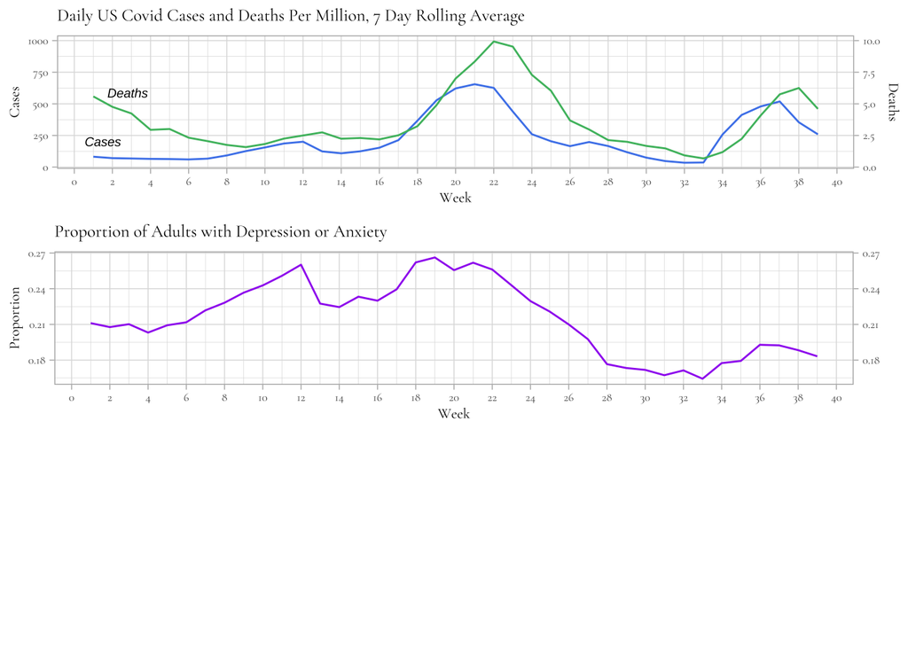

```r
font_add_google("Cormorant Garamond")
font_add_google("EB Garamond")
showtext_auto()

par(mfrow=c(1,2))
# daily cases and deaths, weekly

gridExtra::grid.arrange(
  ggplot(data %>% group_by(WEEK) %>% summarise(cases=mean(new_cases_smoothed_per_million),
                                      deaths=mean(new_deaths_smoothed_per_million),
                                      vax=mean(new_vaccinations_smoothed_per_million)))+
  geom_line(aes(x=WEEK, y=cases), col="#4B85EB") +
  geom_line(aes(x=WEEK, y=deaths*100), col="#4BBB6D") +
  ggtitle("Daily US Covid Cases and Deaths Per Million, 7 Day Rolling Average") +
  labs(x="Week", y="Cases") +
  scale_x_continuous(n.breaks = 20) +
  scale_y_continuous(sec.axis = sec_axis(~./100, name="Deaths"))
  + theme_light()
  + theme(text = element_text(family = "Cormorant Garamond", size=8)) +
  annotate("text", x = 2.8, y = 585, label = "Deaths", size=2.5, fontface="italic") +
  annotate("text", x = 1.5, y = 200, label = "Cases", size=2.5, fontface="italic")
  ,
  ggplot(data %>% group_by(WEEK) %>% summarise(DEP_ANX=mean(DEP_ANX),
                                      ANX=mean(ANX),
                                      DEP=mean(DEP)))+
  geom_line(aes(x=WEEK, y=DEP_ANX), col='purple') +
  # geom_line(aes(x=WEEK, y=ANX),col='red') +
  # geom_line(aes(x=WEEK, y=DEP),col='blue') +
  ggtitle("Proportion of Adults with Depression or Anxiety") +
  labs(x="Week", y="Proportion") +
  scale_x_continuous(n.breaks = 20) +
  scale_y_continuous(sec.axis = sec_axis(~.*1, name=""))
  + theme_light()
  + theme(text = element_text(family = "Cormorant Garamond", size=8))
  ,
  ncol=1, nrow=3
)
```

The figure below visualizes the heterogeneity of trends of the proportion of adults exhibiting depression or anxiety symptoms among subgroups. It appears that individuals reporting higher education levels, higher yearly income, or higher age have better mental health on average. Individuals that identify as Asian or White have the lowest proportions, as well as married and widowed individuals. Males have a significantly lower proportion than women.

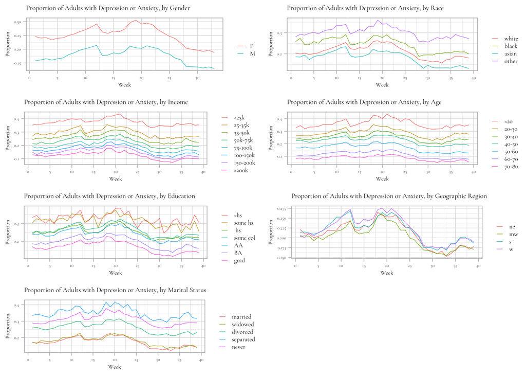

```r
a <- data[,c('WEEK','EGENDER','AGERANGE','INCOME','WRKLOSS','ANYWORK','RRACE',
                'EEDUC','RHISPANIC','THHLD_NUMPER','MS',
                'REGION.y','DIVISION','DEP','ANX','DEP_ANX')]

gridExtra::grid.arrange(

  ggplot(aggregate(a, by=list(a$WEEK, a$EGENDER), FUN=mean)) +
    geom_line(aes(x=Group.1, y=DEP_ANX, group=Group.2, color=Group.2), lwd=0.2) +
    ggtitle("Proportion of Adults with Depression or Anxiety, by Gender") +
    labs(x="Week", y="Proportion", col='') +
    theme_light() +
    theme(text = element_text(family = "Cormorant Garamond", size=5.5),
          legend.key.size = unit(0.5, 'lines'),
          legend.text=element_text(size=6),
          legend.margin=margin(1,1,1,1, unit="pt"),
          legend.box.margin=margin(1,1,1,1, unit="pt")) +
    scale_x_continuous(n.breaks = 10) +
    scale_color_hue(labels = c('F','M')) ,

  ggplot(aggregate(a, by=list(a$WEEK, a$RRACE), FUN=mean)) +
    geom_line(aes(x=Group.1, y=DEP_ANX, group=Group.2, color=Group.2), lwd=0.2) +
    ggtitle("Proportion of Adults with Depression or Anxiety, by Race") +
    labs(x="Week", y="Proportion", col='') +
    scale_color_hue(labels = c("white", "black", "asian", "other")) +
    theme_light() +
    theme(text = element_text(family = "Cormorant Garamond", size=5.5),
          legend.key.size = unit(0.5, 'lines'),
          legend.text=element_text(size=6),
          legend.margin=margin(1,1,1,1, unit="pt"),
          legend.box.margin=margin(1,1,1,1, unit="pt")) +
    scale_x_continuous(n.breaks = 10) ,

  ggplot(aggregate(a, by=list(a$WEEK, a$INCOME), FUN=mean)) +
    geom_line(aes(x=Group.1, y=DEP_ANX, group=Group.2, color=Group.2), lwd=0.2) +
    ggtitle("Proportion of Adults with Depression or Anxiety, by Income") +
    labs(x="Week", y="Proportion", col='') +
    scale_color_hue(labels=c("<25k", "25-35k", "35-50k",
                               "50k-75k", "75-100k", "100-150k",
                               "150-200k", ">200k")) +
    theme_light() +
    theme(text = element_text(family = "Cormorant Garamond", size=5.5),
          legend.key.size = unit(0.5, 'lines'),
          legend.text=element_text(size=6),
          legend.margin=margin(1,1,1,1, unit="pt"),
          legend.box.margin=margin(1,1,1,1, unit="pt")) +
    scale_x_continuous(n.breaks = 10) ,

  ggplot(aggregate(a, by=list(a$WEEK, a$AGERANGE), FUN=mean)) +
    geom_line(aes(x=Group.1, y=DEP_ANX, group=Group.2, color=Group.2), lwd=0.2) +
    ggtitle("Proportion of Adults with Depression or Anxiety, by Age") +
    labs(x="Week", y="Proportion", col='') +
    scale_color_hue(labels=c("<20", "20-30","30-40", "40-50",
                               "50-60", "60-70", "70-80", ">80")) +
    theme_light() +
    theme(text = element_text(family = "Cormorant Garamond", size=5.5),
          legend.key.size = unit(0.5, 'lines'),
          legend.text=element_text(size=6),
          legend.margin=margin(1,1,1,1, unit="pt"),
          legend.box.margin=margin(1,1,1,1, unit="pt")) +
    scale_x_continuous(n.breaks = 10) ,

  ggplot(aggregate(a, by=list(a$WEEK, a$EEDUC), FUN=mean)) +
    geom_line(aes(x=Group.1, y=DEP_ANX, group=Group.2, color=Group.2), lwd=0.2) +
    ggtitle("Proportion of Adults with Depression or Anxiety, by Education") +
    labs(x="Week", y="Proportion", col='') +
    scale_color_hue(labels=c("<hs", "some hs", " hs", "some col",
                               "AA", "BA", "grad")) +
    theme_light() +
    theme(text = element_text(family = "Cormorant Garamond", size=5.5),
          legend.key.size = unit(0.5, 'lines'),
          legend.text=element_text(size=6),
          legend.margin=margin(1,1,1,1, unit="pt"),
          legend.box.margin=margin(1,1,1,1, unit="pt")) +
    scale_x_continuous(n.breaks = 10) ,

  ggplot(aggregate(a, by=list(a$WEEK, a$REGION.y), FUN=mean)) +
    geom_line(aes(x=Group.1, y=DEP_ANX, group=Group.2, color=Group.2), lwd=0.2) +
    ggtitle("Proportion of Adults with Depression or Anxiety, by Geographic Region") +
    labs(x="Week", y="Proportion", col='') +
    theme_light() +
    theme(text = element_text(family = "Cormorant Garamond", size=5.5),
          legend.key.size = unit(0.5, 'lines'),
          legend.text=element_text(size=6),
          legend.margin=margin(1,1,1,1, unit="pt"),
          legend.box.margin=margin(1,1,1,1, unit="pt")) +
    scale_x_continuous(n.breaks = 10) +
    scale_color_hue(labels = c("ne", "mw", "s", "w")) ,

  ggplot(aggregate(a, by=list(a$WEEK, a$MS), FUN=mean)) +
    geom_line(aes(x=Group.1, y=DEP_ANX, group=Group.2, color=Group.2), lwd=0.2) +
    ggtitle("Proportion of Adults with Depression or Anxiety, by Marital Status") +
    labs(x="Week", y="Proportion", col='') +
    scale_color_hue(labels=c("married","widowed","divorced","separated","never"))+
    theme_light() +
    theme(text = element_text(family = "Cormorant Garamond", size=5.5),
          legend.key.size = unit(0.5, 'lines'),
          legend.text=element_text(size=6),
          legend.margin=margin(1,1,1,1, unit="pt"),
          legend.box.margin=margin(1,1,1,1, unit="pt")) +
    scale_x_continuous(n.breaks = 10) ,
  ncol=2
)
```

### Results

```r
# GLM LOGIT MODEL
reg1 <- glm(DEP_ANX ~ new_deaths_smoothed_per_million+
             EGENDER+MS+INCOME+AGERANGE+RHISPANIC+RRACE+EEDUC+REGION.y,
            data=data,family ='binomial', na.action=na.omit)

reg2 <- glm(DEP_ANX ~ new_cases_smoothed_per_million+
             EGENDER+MS+INCOME+AGERANGE+RHISPANIC+RRACE+EEDUC+REGION.y,
            data=data,family ='binomial', na.action=na.omit)

stargazer(reg1, reg2,
          summary = F, font.size = 'scriptsize',
          column.sep.width = "1pt",  single.row = T,
          header=F, title = 'Logistic Regression Results',
          dep.var.labels = "Proportion Adults with Depression or Anxiety",
          no.space = T,
          covariate.labels = c("deaths","cases","gender-male",
                               "MS-widowed","MS-divorced","MS-separated","MS-never",
                               "income 25-35k", "income 35-50k",
                               "income 50-75k", "income 75-100k", "income 100-150k",
                               "income 150-200k", "income >200k",
                               "age 30-40", "age 40-50","age 50-60",
                               "age 60-70", "age 70-80", "age >80",
                               "nonhispanic",
                               "race-black", "race-asian", "race-other",
                               "educ-some hs", "educ- hs", "educ-some col",
                               "educ-AA", "educ-BA", "educ-grad",
                               "region-mw", "region-s", "region-w",
                               "Constant"))
```

[output not shown]

Regarding the heterogeneity of trends among subgroups, I observe the following:

### Discussion

As expected, increased daily Covid deaths is associated with a 3.3% increase in odds of experiencing anxiety and depression. However, increased daily Covid cases is associated with a much smaller 0.1% increase. This may be because the effect of Covid cases is variable across local geographical regions: different regions experienced waves of cases at different times. By contrast, Covid deaths may have been more broadcasted across media, affecting the general public more jointly. Further analysis among smaller regions within the US may yield more accurate estimates of the association between Covid deaths or cases and mental health.

Given these findings, it is crucial for US policy-makers to not only pursue policies that effectively fight the spread of Covid, but also bridge the mental health gap for minority groups. Indeed, this gap was likely a preexisting trend exacerbated by the pandemic. Policy-makers should consider encouraging lower education individuals to pursue higher education, for example by creating accessible, low-cost academic programs and scholarships. In addition, policy-makers should give minorities greater access to mental health services, for example by expanding telehealth programs and subsidizing costs of services.

Regarding global implications, a possible extension of my study is to examine temporal trends of mental health across different countries during the COVID-19 pandemic. By comparing two demographically similar countries that suffered Covid outbreaks at different times (for example, the United States and Canada), it may be possible to estimate the causal effect of the COVID-19 pandemic on mental health [@Alfano_2020]. For instance, while stay-at-home orders are effective in fighting the spread of Covid [@Friedson_2020], they may have adverse effects on the population’s mental health [@Xu_2020]. These findings will push policy-makers to take mental health into consideration when desinging policies in future global emergencies and economic downturns.